# Programa de Pós-graduação em Computação Aplicada – PPCA (UnB)

### 5.3 Distribuição dos resíduos

Índice

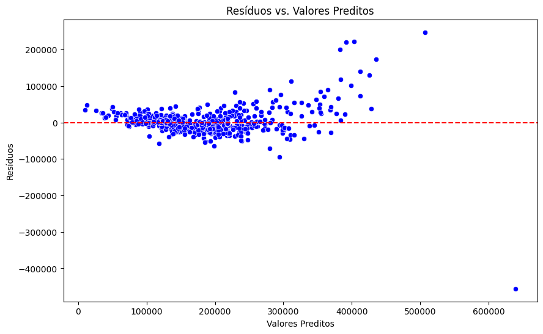

```python
plt.figure(figsize=(10, 6))
sns.scatterplot(x=y_pred_test, y=residuals, color="blue")
plt.axhline(0, linestyle="--", color="red")
plt.title("Resíduos vs. Valores Preditos")
plt.xlabel("Valores Preditos")
plt.ylabel("Resíduos")
plt.show()
```

Os resíduos não estão uniformemente distribuídos ao longo da linha central (linha vermelha em zero). Existe um padrão de aumento na variância dos resíduos para valores preditos maiores, sugerindo que o modelo apresenta heterocedasticidade, ou seja, a variabilidade dos resíduos não é constante, fere pressupostos de uma regressão linear. Além de pontos distantes do centro, especialmente em valores preditos altos, indicam potenciais outliers ou casos que o modelo não conseguiu ajustar bem.

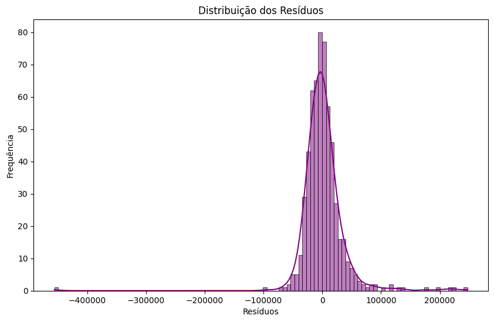

```python
plt.figure(figsize=(10, 6))
sns.histplot(residuals, kde=True, color="purple")
plt.title("Distribuição dos Resíduos")
plt.xlabel("Resíduos")
plt.ylabel("Frequência")
plt.show()
```

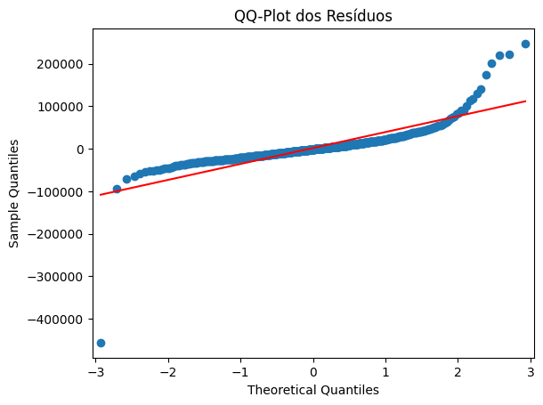

```python
sm.qqplot(residuals, line="s")
plt.title("QQ-Plot dos Resíduos")
plt.show()
```

Em um modelo ideal com resíduos normais, os pontos devem estar alinhados com a linha vermelha. Nos quantis centrais (em torno de zero), os resíduos seguem razoavelmente a linha de referência, indicando uma aproximação da normalidade para a maior parte dos dados. Muito embora, nos extremos, há desvios significativos da linha, com resíduos nas caudas (tanto inferiores quanto superiores) afastando-se da normalidade. Isso sugere a presença de outliers ou resíduos que não seguem bem a distribuição normal.

```python
print("Média dos resíduos:", np.mean(residuals))
print("Desvio padrão dos resíduos:", np.std(residuals))
```

```
Média dos resíduos: 1820.1445778434927
Desvio padrão dos resíduos: 37504.504977313256
```

## 6. Conclusões

O modelo de regressão linear ajustado apresentou um R² de 0,8, indicando que 80% da variabilidade do preço de venda das propriedades `SalePrice` pode ser explicada pelas variáveis explicativas selecionadas. Este resultado, à primeira vista, sugere uma boa capacidade preditiva. Contudo, é importante destacar que métricas de desempenho, por si só, não garantem a adequação estatística do modelo, especialmente quando os pressupostos fundamentais da regressão linear são violados.

Durante a etapa de análise exploratória de dados (EDA), identificamos indícios de fragilidade nos dados, como distribuições assimétricas, outliers e possível multicolinearidade entre as variáveis. Essas características foram confirmadas durante a avaliação dos resíduos e dos pressupostos do modelo. Os gráficos residuais indicaram a presença de padrões não aleatórios, heterocedasticidade e desvios significativos da normalidade, comprometendo a validade inferencial do modelo. Além disso, o cálculo do VIF revelou multicolinearidade em algumas variáveis, o que pode influenciar negativamente as estimativas dos coeficientes.

Com base no framework CRISP-DM, é evidente que o modelo deve retornar à fase de preparação e pré-processamento dos dados. Nesta etapa, será essencial adotar estratégias como transformações nas variáveis (ex.: logaritmo ou padronização), remoção ou tratamento de outliers, e redução de multicolinearidade, seja por meio de seleção de variáveis ou métodos de regularização, como Ridge ou Lasso.

Somente após um pré-processamento robusto, o modelo poderá ser reavaliado para garantir que atenda tanto aos pressupostos estatísticos quanto às métricas preditivas esperadas. Este ciclo de refinamento, conforme preconizado pelo CRISP-DM, é essencial para garantir um modelo confiável e interpretável, capaz de oferecer insights práticos e fundamentados sobre o impacto das características das propriedades no preço de venda.

Índice

## 7. Bibliografia

Índice

GUJARATI, D. N., & Porter, D. C. (2009). Basic Econometrics (5th ed.). McGraw-Hill Education.

SILVA, Anderson Rodrigo da. Estatística decodificada. São Paulo: Editora Blucher, 2023. E-book. p.167. ISBN 9786555063585. Disponível em: https://unibb.minhabiblioteca.com.br/reader/books/9786555063585/. Acesso em: 15 dez. 2024.

SHEARER, C. (2000). The CRISP-DM Model: The New Blueprint for Data Mining. Journal of Data Warehousing, 5(4), 13–22.